# Lab 4

Vista Sohrab

9/14/2020

## Loading Libraries and COVID-19 Data from the John Hopkins University (JHU) interactive dashboard

Load necessary libraries for this lab into the environment.

```r
library(tidyverse)
library(DT)
```

Import March 11, 2020 COVID-19 data from the JHU interactive dashboard GitHub repository, and change the column names containing “/”to "_" to prevent downstream errors from occurring.

```r
report_03_11_2020 <- read_csv(url("https://github.com/CSSEGISandData/COVID-19/raw/master/csse_covid_19_data/csse_covid_19_daily_reports/03-11-2020.csv")) %>%
  rename(Country_Region = "Country/Region", Province_State = "Province/State")
```

Checking the structure of the datatable to ensure that everything is as expected:

```r
str(report_03_11_2020)
```

```
## Classes 'spec_tbl_df', 'tbl_df', 'tbl' and 'data.frame': 216 obs. of  8 variables:
##  $ Province_State: chr  "Hubei" NA NA NA ...
##  $ Country_Region: chr  "China" "Italy" "Iran" "Korea, South" ...
##  $ Last Update   : POSIXct, format: "2020-03-11 10:53:02" "2020-03-11 21:33:02" ...
##  $ Confirmed     : num  67773 12462 9000 7755 2281 ...
##  $ Deaths        : num  3046 827 354 60 48 ...
##  $ Recovered     : num  49134 1045 2959 288 12 ...
##  $ Latitude      : num  31 43 32 36 46.2 ...
##  $ Longitude     : num  112.27 12 53 128 2.21 ...
##  - attr(*, "spec")=
##   .. cols(
##   ..   `Province/State` = col_character(),
##   ..   `Country/Region` = col_character(),
##   ..   `Last Update` = col_datetime(format = ""),
##   ..   Confirmed = col_double(),
##   ..   Deaths = col_double(),
##   ..   Recovered = col_double(),
##   ..   Latitude = col_double(),
##   ..   Longitude = col_double()
##   .. )
```

## Interactive Data Tables

```r
datatable(report_03_11_2020)
```

|  | Province_State | Country_Region | Last Update | Confirmed | Deaths | Recovered | Latitude | Longitude |
| --- | --- | --- | --- | --- | --- | --- | --- | --- |
| 1 | Hubei | China | 2020-03-11T10:53:02Z | 67773 | 3046 | 49134 | 30.9756 | 112.2707 |
| 2 |  | Italy | 2020-03-11T21:33:02Z | 12462 | 827 | 1045 | 43 | 12 |
| 3 |  | Iran | 2020-03-11T18:52:03Z | 9000 | 354 | 2959 | 32 | 53 |
| 4 |  | Korea, South | 2020-03-11T21:13:18Z | 7755 | 60 | 288 | 36 | 128 |
| 5 | France | France | 2020-03-11T22:53:03Z | 2281 | 48 | 12 | 46.2276 | 2.2137 |
| 6 |  | Spain | 2020-03-11T20:53:02Z | 2277 | 54 | 183 | 40 | -4 |
| 7 |  | Germany | 2020-03-11T19:13:17Z | 1908 | 3 | 25 | 51 | 9 |
| 8 | Guangdong | China | 2020-03-11T10:13:06Z | 1356 | 8 | 1282 | 23.3417 | 113.4244 |
| 9 | Henan | China | 2020-03-11T08:13:09Z | 1273 | 22 | 1249 | 33.882 | 113.614 |
| 10 | Zhejiang | China | 2020-03-11T09:33:12Z | 1215 | 1 | 1195 | 29.1832 | 120.0934 |

[output cut: 206 more lines]

## Exercises (Part 1)

1. The recent COVID-19 data set from September 13, 2020 has additional columns when compared to the March 13, 2020 dataset. FIPS, Admin2, Active, Combined_Key,Incidence_Rate, and Case-Fatility_Ratio are the 6 columns that have been added to the most recent dataset.

```r
report_03_13_2020 <- read_csv(url("https://github.com/CSSEGISandData/COVID-19/raw/master/csse_covid_19_data/csse_covid_19_daily_reports/03-13-2020.csv")) %>%
  rename(Country_Region = "Country/Region", Province_State = "Province/State")
report_09_13_2020 <- read_csv(url("https://github.com/CSSEGISandData/COVID-19/raw/master/csse_covid_19_data/csse_covid_19_daily_reports/09-13-2020.csv"))
str(report_03_13_2020)
```

```
## Classes 'spec_tbl_df', 'tbl_df', 'tbl' and 'data.frame': 230 obs. of  8 variables:
##  $ Province_State: chr  "Hubei" "Guangdong" "Henan" "Zhejiang" ...
##  $ Country_Region: chr  "China" "China" "China" "China" ...
##  $ Last Update   : POSIXct, format: "2020-03-13 11:09:03" "2020-03-13 11:09:03" ...
##  $ Confirmed     : num  67786 1356 1273 1215 1018 ...
##  $ Deaths        : num  3062 8 22 1 4 ...
##  $ Recovered     : num  51553 1296 1249 1197 1005 ...
##  $ Latitude      : num  31 23.3 33.9 29.2 27.6 ...
##  $ Longitude     : num  112 113 114 120 112 ...
##  - attr(*, "spec")=
##   .. cols(
##   ..   `Province/State` = col_character(),
##   ..   `Country/Region` = col_character(),
##   ..   `Last Update` = col_datetime(format = ""),
##   ..   Confirmed = col_double(),
##   ..   Deaths = col_double(),
##   ..   Recovered = col_double(),
##   ..   Latitude = col_double(),
##   ..   Longitude = col_double()
##   .. )
```

```r
str(report_09_13_2020)
```

```
## Classes 'spec_tbl_df', 'tbl_df', 'tbl' and 'data.frame': 3954 obs. of  14 variables:
##  $ FIPS               : num  NA NA NA NA NA NA NA NA NA NA ...
##  $ Admin2             : chr  NA NA NA NA ...
##  $ Province_State     : chr  NA NA NA NA ...
##  $ Country_Region     : chr  "Afghanistan" "Albania" "Algeria" "Andorra" ...
##  $ Last_Update        : POSIXct, format: "2020-09-14 04:26:09" "2020-09-14 04:26:09" ...
##  $ Lat                : num  33.9 41.2 28 42.5 -11.2 ...
##  $ Long_              : num  67.71 20.17 1.66 1.52 17.87 ...
##  $ Confirmed          : num  38716 11353 48254 1344 3388 ...
##  $ Deaths             : num  1420 334 1612 53 134 ...
##  $ Recovered          : num  31638 6569 34037 943 1301 ...
##  $ Active             : num  5658 4450 12605 348 1953 ...
##  $ Combined_Key       : chr  "Afghanistan" "Albania" "Algeria" "Andorra" ...
##  $ Incidence_Rate     : num  99.5 394.5 110 1739.5 10.3 ...
##  $ Case-Fatality_Ratio: num  3.67 2.94 3.34 3.94 3.96 ...
##  - attr(*, "spec")=
##   .. cols(
##   ..   FIPS = col_double(),
##   ..   Admin2 = col_character(),
##   ..   Province_State = col_character(),
##   ..   Country_Region = col_character(),
##   ..   Last_Update = col_datetime(format = ""),
##   ..   Lat = col_double(),
##   ..   Long_ = col_double(),
##   ..   Confirmed = col_double(),
##   ..   Deaths = col_double(),
##   ..   Recovered = col_double(),
##   ..   Active = col_double(),
##   ..   Combined_Key = col_character(),
##   ..   Incidence_Rate = col_double(),
##   ..   `Case-Fatality_Ratio` = col_double()
##   .. )
```

2. A dataframe containing total counts of confirmed, deaths, and recoveries for every country based on March 13, 2020 COVID-19 dataset.

```r
report_03_13_2020 %>%
  group_by(Country_Region) %>%
  summarize(Total_Confirmed = sum(Confirmed), Total_Deaths = sum(Deaths), Total_Recovered = sum(Recovered)) %>%
  datatable()
```

|  | Country_Region | Total_Confirmed | Total_Deaths | Total_Recovered |
| --- | --- | --- | --- | --- |
| 1 | Afghanistan | 7 | 0 | 0 |
| 2 | Albania | 33 | 1 | 0 |
| 3 | Algeria | 26 | 2 | 8 |
| 4 | Andorra | 1 | 0 | 0 |
| 5 | Antigua and Barbuda | 1 | 0 | 0 |
| 6 | Argentina | 31 | 2 | 0 |
| 7 | Armenia | 8 | 0 | 0 |
| 8 | Aruba | 2 | 0 | 0 |
| 9 | Australia | 200 | 3 | 23 |
| 10 | Austria | 504 | 1 | 6 |

[output cut: 115 more lines]

A dataframe containing total counts of confirmed, deaths, and recoveries for every country based on most recent September 13, 2020 COVID-19 dataset.

```r
report_09_13_2020 %>%
  group_by(Country_Region) %>%
  summarize(Total_Confirmed = sum(Confirmed), Total_Deaths = sum(Deaths), Total_Recovered = sum(Recovered)) %>%
  datatable()
```

|  | Country_Region | Total_Confirmed | Total_Deaths | Total_Recovered |
| --- | --- | --- | --- | --- |
| 1 | Afghanistan | 38716 | 1420 | 31638 |
| 2 | Albania | 11353 | 334 | 6569 |
| 3 | Algeria | 48254 | 1612 | 34037 |
| 4 | Andorra | 1344 | 53 | 943 |
| 5 | Angola | 3388 | 134 | 1301 |
| 6 | Antigua and Barbuda | 95 | 3 | 91 |
| 7 | Argentina | 555537 | 11352 | 419513 |
| 8 | Armenia | 45862 | 916 | 41659 |
| 9 | Australia | 26692 | 816 | 23463 |
| 10 | Austria | 33159 | 756 | 26760 |

[output cut: 178 more lines]

3. Counts of confirmed cases in the United States per state from March 13, 2020 is as follows

```r
report_03_13_2020 %>%
  filter(Country_Region == "US") %>%
  group_by(Province_State) %>%
  summarize(Confirmed) %>%
  datatable()
```

|  | Province_State | Confirmed |
| --- | --- | --- |
| 1 | Alabama | 5 |
| 2 | Alaska | 1 |
| 3 | Arizona | 9 |
| 4 | Arkansas | 6 |
| 5 | California | 282 |
| 6 | Colorado | 49 |
| 7 | Connecticut | 11 |
| 8 | Delaware | 4 |
| 9 | Diamond Princess | 46 |
| 10 | District of Columbia | 10 |

[output cut: 43 more lines]

Counts of confirmed cases in the United States per state from September 13, 2020 is the following:

```r
report_09_13_2020 %>%
  filter(Country_Region == "US") %>%
  group_by(Province_State) %>%
  summarize(sum(Confirmed)) %>%
  datatable()
```

|  | Province_State | sum(Confirmed) |
| --- | --- | --- |
| 1 | Alabama | 138755 |
| 2 | Alaska | 6268 |
| 3 | Arizona | 208512 |
| 4 | Arkansas | 70219 |
| 5 | California | 761728 |
| 6 | Colorado | 61293 |
| 7 | Connecticut | 54326 |
| 8 | Delaware | 18849 |
| 9 | Diamond Princess | 49 |
| 10 | District of Columbia | 14592 |

[output cut: 48 more lines]

4. The top 10 countries for COVID-19 deaths based on the March 13, 2020 dataset is in the datatable below.

```r
report_03_13_2020 %>%
  group_by(Country_Region) %>%
  summarize(Total_Deaths = sum(Deaths)) %>%
  arrange(desc(Total_Deaths)) %>%
  slice(1:10) %>%
  datatable()
```

|  | Country_Region | Total_Deaths |
| --- | --- | --- |
| 1 | China | 3180 |
| 2 | Italy | 1266 |
| 3 | Iran | 514 |
| 4 | Spain | 133 |
| 5 | France | 79 |
| 6 | Korea, South | 66 |
| 7 | US | 47 |
| 8 | Japan | 19 |
| 9 | Switzerland | 11 |
| 10 | Netherlands | 10 |

The top 10 countries for COVID-19 deaths six months later based on the September 13, 2020 dataset is in the datatable below.

```r
report_09_13_2020 %>%
  group_by(Country_Region) %>%
  summarize(Total_Deaths = sum(Deaths)) %>%
  arrange(desc(Total_Deaths)) %>%
  slice(1:10) %>%
  datatable()
```

|  | Country_Region | Total_Deaths |
| --- | --- | --- |
| 1 | US | 194071 |
| 2 | Brazil | 131625 |
| 3 | India | 78586 |
| 4 | Mexico | 70821 |
| 5 | United Kingdom | 41717 |
| 6 | Italy | 35610 |
| 7 | France | 30903 |
| 8 | Peru | 30526 |
| 9 | Spain | 29747 |
| 10 | Iran | 23157 |

## Exercises (Part 2)

```r
#Import March 12th and September 12th dataframes from JHU CSSE COVID-19 GitHub repository
report_03_12_2020 <- read_csv(url("https://github.com/CSSEGISandData/COVID-19/raw/master/csse_covid_19_data/csse_covid_19_daily_reports/03-12-2020.csv")) %>%
  rename(Country_Region = "Country/Region", Province_State = "Province/State")
report_09_12_2020 <- read_csv(url("https://github.com/CSSEGISandData/COVID-19/raw/master/csse_covid_19_data/csse_covid_19_daily_reports/09-12-2020.csv"))
#Create 10 countries with highest COVID-19 confirmed cases and deaths for the two different dates
#March 12, 2020
March_Top10 <- report_03_12_2020 %>%
  group_by(Country_Region) %>%
  summarize(Total_Confirmed = sum(Confirmed), Total_Deaths = sum(Deaths)) %>%
  arrange(desc(Total_Deaths)) %>%
  slice(1:10)

datatable(March_Top10)
```

|  | Country_Region | Total_Confirmed | Total_Deaths |
| --- | --- | --- | --- |
| 1 | China | 80932 | 3172 |
| 2 | Italy | 12462 | 827 |
| 3 | Iran | 10075 | 429 |
| 4 | Korea, South | 7869 | 66 |
| 5 | Spain | 2277 | 55 |
| 6 | France | 2284 | 48 |
| 7 | US | 1663 | 40 |
| 8 | Japan | 639 | 16 |
| 9 | Iraq | 71 | 8 |
| 10 | United Kingdom | 459 | 8 |

```r
#September 12, 2020
Sept_Top10 <- report_09_12_2020 %>%
  group_by(Country_Region) %>%
  summarize(Total_Confirmed = sum(Confirmed), Total_Deaths = sum(Deaths)) %>%
  arrange(desc(Total_Deaths)) %>%
  slice(1:10)

datatable(Sept_Top10)
```

|  | Country_Region | Total_Confirmed | Total_Deaths |
| --- | --- | --- | --- |
| 1 | US | 6485214 | 193693 |
| 2 | Brazil | 4315687 | 131210 |
| 3 | India | 4754356 | 78586 |
| 4 | Mexico | 663973 | 70604 |
| 5 | United Kingdom | 367592 | 41712 |
| 6 | Italy | 286297 | 35603 |
| 7 | France | 402811 | 30902 |
| 8 | Peru | 716670 | 30470 |
| 9 | Spain | 566326 | 29747 |
| 10 | Iran | 399940 | 23029 |

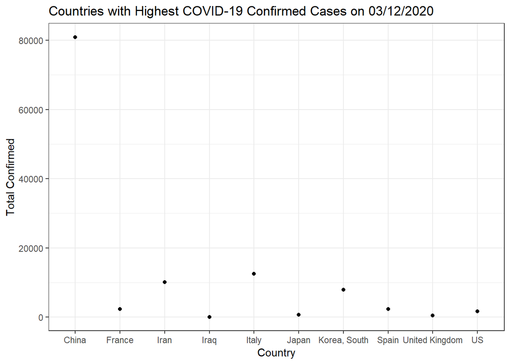

```r
#March 12, 2020 scatterplot Confirmed Cases
ggplot() + geom_point(data=March_Top10, mapping = aes(March_Top10$Country_Region, March_Top10$Total_Confirmed)) + xlab("Country") + ylab("Total Confirmed") + ggtitle("Countries with Highest COVID-19 Confirmed Cases on 03/12/2020") + theme_bw()
```

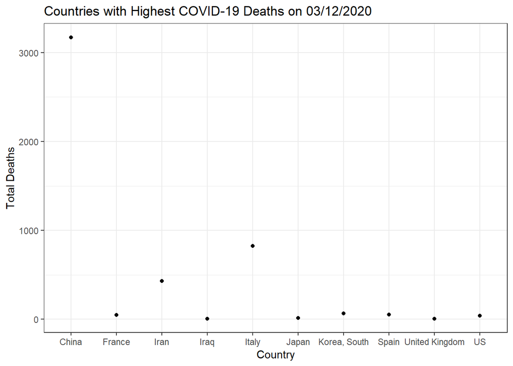

```r
#March 12, 2020 scatterplot COVID-19 Deaths
ggplot() + geom_point(data=March_Top10, mapping = aes(March_Top10$Country_Region, March_Top10$Total_Deaths)) + xlab("Country") + ylab("Total Deaths") + ggtitle("Countries with Highest COVID-19 Deaths on 03/12/2020") + theme_bw()
```

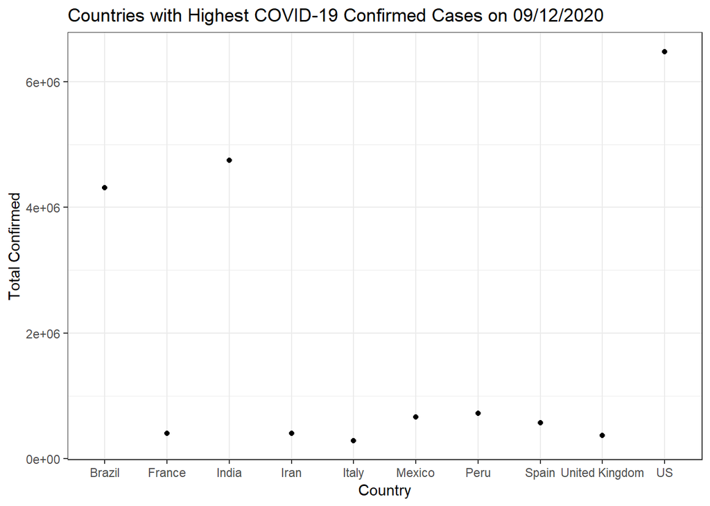

```r
#September 12, 2020 scatterplot Total Confirmed Cases
ggplot() + geom_point(data=Sept_Top10, mapping = aes(Sept_Top10$Country_Region, Sept_Top10$Total_Confirmed)) + xlab("Country") + ylab("Total Confirmed") + ggtitle("Countries with Highest COVID-19 Confirmed Cases on 09/12/2020") + theme_bw()
```

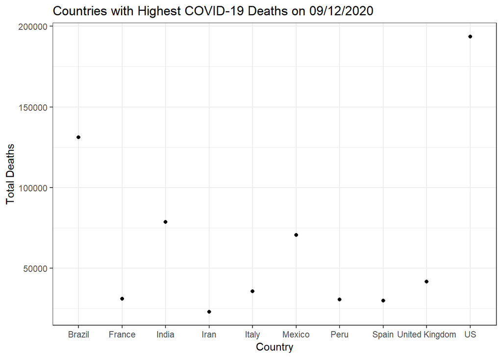

```r
#September 12, 2020 scatterplot Total Deaths
ggplot() + geom_point(data=Sept_Top10, mapping = aes(Sept_Top10$Country_Region, Sept_Top10$Total_Deaths)) + xlab("Country") + ylab("Total Deaths") + ggtitle("Countries with Highest COVID-19 Deaths on 09/12/2020") + theme_bw()
```

6. Barplots of US states with highest confirmed cases and deaths related to COVID-19 in March and September are shown in the following sections. First the respective data tables are obtained.

```r
US_states_Mar2020 <- report_03_12_2020%>%
  filter(Country_Region == "US") %>%
  group_by(Province_State) %>%
  summarize(Confirmed, Deaths)%>%
  arrange(desc(Confirmed,Deaths)) %>%
  slice(1:10)

  datatable(US_states_Mar2020)
```

|  | Province_State | Confirmed | Deaths |
| --- | --- | --- | --- |
| 1 | Washington | 442 | 31 |
| 2 | New York | 328 | 0 |
| 3 | California | 221 | 4 |
| 4 | Massachusetts | 108 | 0 |
| 5 | Diamond Princess | 46 | 0 |
| 6 | Colorado | 45 | 0 |
| 7 | Florida | 35 | 2 |
| 8 | Illinois | 32 | 0 |
| 9 | Georgia | 31 | 1 |
| 10 | New Jersey | 29 | 1 |

```r
US_states_Sept2020 <- report_09_12_2020%>%
  filter(Country_Region == "US") %>%
  group_by(Province_State) %>%
  summarize(Total_Confirmed = sum(Confirmed), Total_Deaths = sum(Deaths)) %>%
  arrange(desc(Total_Confirmed, Total_Deaths)) %>%
  slice(1:10)

  datatable(US_states_Sept2020)
```

|  | Province_State | Total_Confirmed | Total_Deaths |
| --- | --- | --- | --- |
| 1 | California | 758933 | 14327 |
| 2 | Texas | 677716 | 14332 |
| 3 | Florida | 661571 | 12600 |
| 4 | New York | 443640 | 33023 |
| 5 | Georgia | 292905 | 6287 |
| 6 | Illinois | 261999 | 8527 |
| 7 | Arizona | 208128 | 5315 |
| 8 | New Jersey | 196337 | 16027 |
| 9 | North Carolina | 183738 | 3047 |
| 10 | Tennessee | 170891 | 2064 |

Two bar plots for March 2020 and September 2020 highest ranking US states with confirmed COVID-19 cases.

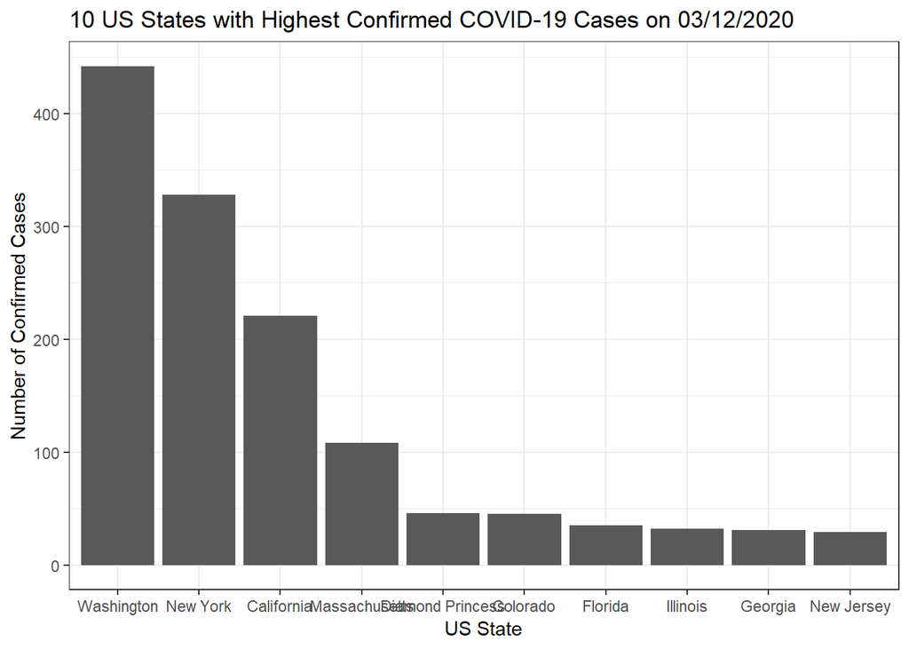

```r
ggplot(data=US_states_Mar2020, aes(reorder(US_states_Mar2020$Province_State,-US_states_Mar2020$Confirmed), US_states_Mar2020$Confirmed)) + geom_bar(stat= "identity") + xlab("US State") + ylab("Number of Confirmed Cases") + ggtitle("10 US States with Highest Confirmed COVID-19 Cases on 03/12/2020") + theme_bw()
```

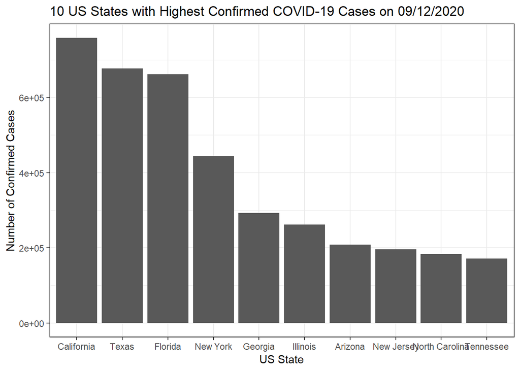

```r
ggplot(data=US_states_Sept2020, aes(reorder(US_states_Sept2020$Province_State,-US_states_Sept2020$Total_Confirmed), US_states_Sept2020$Total_Confirmed)) + geom_bar(stat= "identity") + xlab("US State") + ylab("Number of Confirmed Cases") + ggtitle("10 US States with Highest Confirmed COVID-19 Cases on 09/12/2020")+ theme_bw()
```

Two bar plots for March 2020 and September 2020 highest ranking US states with COVID-19 related deaths.

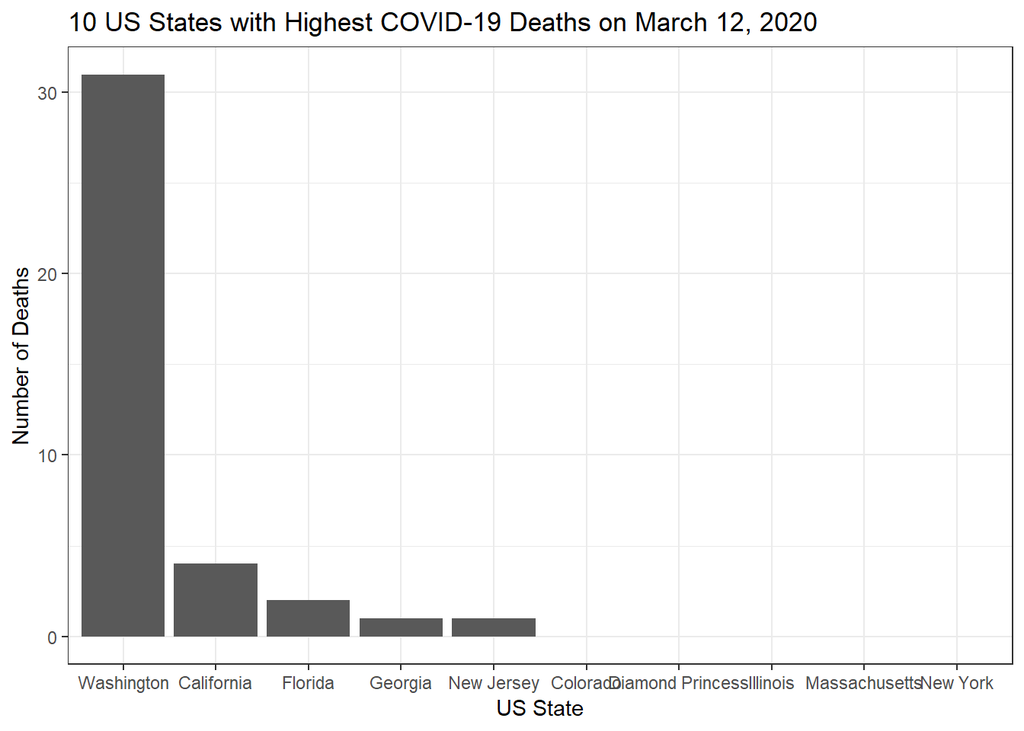

```r
ggplot(data=US_states_Mar2020, aes(reorder(US_states_Mar2020$Province_State,-US_states_Mar2020$Deaths), US_states_Mar2020$Deaths)) + geom_bar(stat="identity") + scale_x_discrete(drop = TRUE)+ xlab("US State") + ggtitle("10 US States with Highest COVID-19 Deaths on March 12, 2020") + ylab("Number of Deaths")+ theme_bw()
```

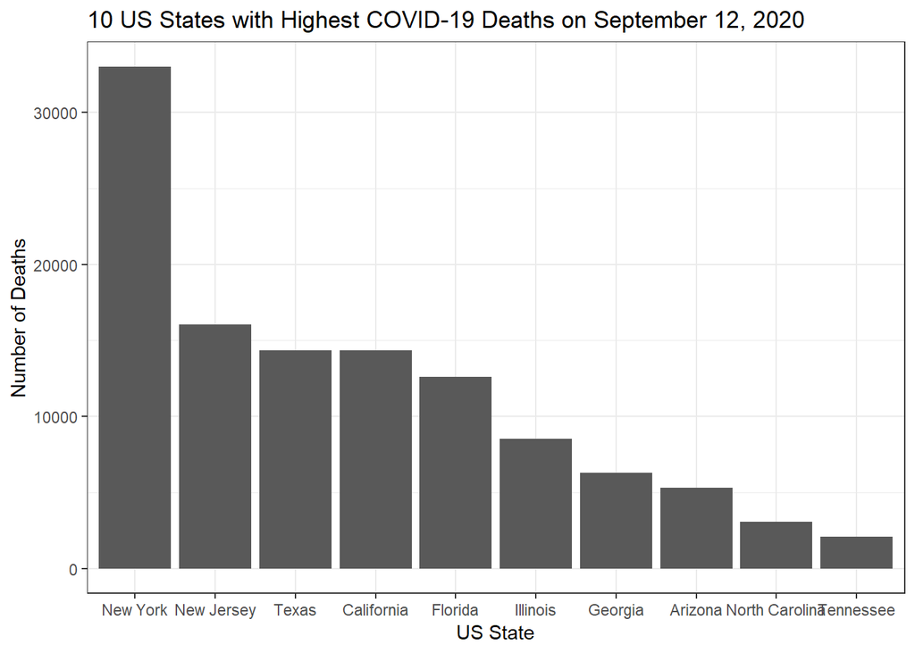

```r
ggplot(data=US_states_Sept2020, aes(reorder(US_states_Sept2020$Province_State,-US_states_Sept2020$Total_Deaths), US_states_Sept2020$Total_Deaths)) + geom_bar(stat= "identity") + xlab("US State") + ylab("Number of Deaths") + ggtitle("10 US States with Highest COVID-19 Deaths on September 12, 2020") + theme_bw()
```